# [LINK] [ALL] [PORTAL]

James Riley

2019-10-24

# The world is not as it seems…

Niantic (of Pokemon Go and Harry Potter Wizards Unite) have [Ingress](https://ingress.com/) as their first game. Gameplay is very basic compared to the other games, which goes a long way to explaining why I put Ingress down for a long time when Pokemon Go started.

I’ve hit a slump in Po Go, and picked Ingress back up. I might come back and talk about the lore, but for the purposes of this post:

- The ‘Shapers’ are pan-dimensional beings that throw ‘exotic matter’ into our universe through portals, and we react to this by bulding points of interest there.
- The green team (Enlightened) believe that the Shapers want to be our friends.
- The blue team (Resistance) believe that the Shapers are sinister.
- We play the game by physically walking to a portal and interacting with it on our phones.
- There’s a minigame that’s approximately Simon Says with alien glyphs that make certain messages.

I’m trying to get better at remembering the glyphs, so I’ve been looking up lists of glyphs and stuff. [This Javascript example](http://gm9.github.io/ingress-glyph-tools/) has been handy, but I’ve got a few ideas floating around for playing with glyphs, and a whole bunch of them rely on a sensible glyph package. I grabbed their JS encoding of the glyphs, it needs a bit more cleanup before I’d call it a final version, but it’ll work for today.

# Enter GliphR

Unusually for me, most of the actual code for this post is tucked away somewhere else, since I put a basic version of GliphR together today - [GitHub](https://github.com/jimr1603/GlyphR).

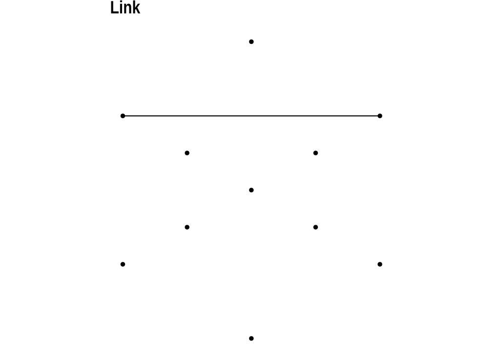

```r
glyphs %>%
  filter(names=="Link") %>%
  distinct() %>% #2 copies of the same thing :( Must do cleanup
  pull(edgelist) %>%
  edgelist_to_tbl() %>%
  glyph_graph() %>%
  GlyphR:::ggliph()  + # Need to go back and export this fn
   geom_edge_link() + geom_node_point() + ggtitle("Link") + coord_fixed()
```

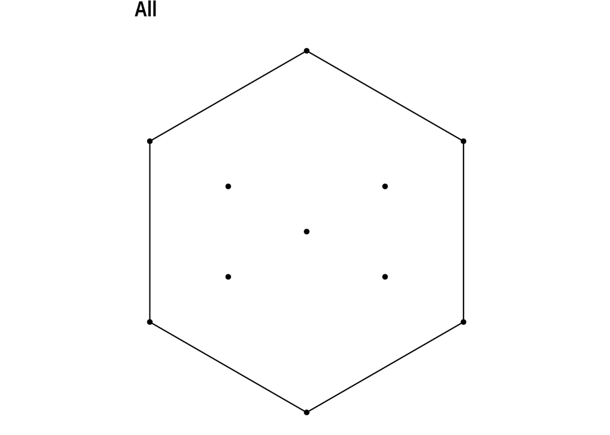

```r
glyphs %>%
  filter(names=="All") %>%
  distinct() %>% #2 copies of the same thing :( Must do cleanup
  pull(edgelist) %>%
  edgelist_to_tbl() %>%
  glyph_graph() %>%
  GlyphR:::ggliph()  + # Need to go back and export this fn
   geom_edge_link() + geom_node_point() + ggtitle("All") + coord_fixed()
```

[figure not shown]

```r
glyphs %>%
  filter(str_detect(names,"Portal")) %>%
  distinct() %>% #2 copies of the same thing :( Must do cleanup
  pull(edgelist) %>%
  edgelist_to_tbl() %>%
  glyph_graph() %>%
  GlyphR:::ggliph()  + # Need to go back and export this fn
   geom_edge_link() + geom_node_point() + ggtitle("Field") + coord_fixed()
```

# GitHub Issues as todo list

I’m finding problems as I’m trying to use the library, and adding them to my [GitHub Issues](https://github.com/jimr1603/GlyphR/issues) as I go. It’s a nice way of dealing with stuff.

# Building on top of existing

Those are ggplots/tidygraphs, I can play with how they’re displayed.

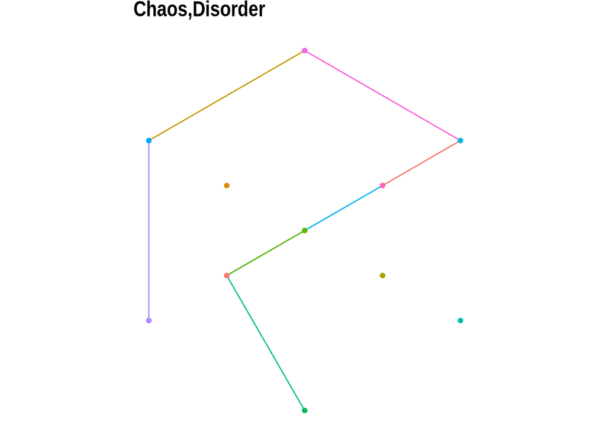

```r
entry <-glyphs %>%
  filter(str_starts(names, "Chaos"))%>%
  distinct()

  entry %>% #2 copies of the same thing :( Must do cleanup
  pull(edgelist) %>%
  edgelist_to_tbl() %>%
  glyph_graph() %>%
  GlyphR:::ggliph()  + # Need to go back and export this fn
   geom_edge_link(aes(colour=sample(1:7, 7) %>% as.factor())) + geom_node_point(aes(colour=sample(1:11, 11) %>% as.factor)) + ggtitle(entry$names) + coord_fixed() +
    scale_color_hue() + theme(legend.position = "none")
```

Yes, I deliberately made the ugliest graph I could.